# A/B-тестирование

## Постановка задачи

Задача — провести оценку результатов A/B-теста. В наличии есть датасет с действиями пользователей, техническое задание и несколько вспомогательных датасетов. Необходимо:

- Оценить корректность проведения теста,
- Проанализировать результаты теста.

Для оценки корректности проведения теста, необходимо проверить:

- пересечение тестовой аудитории с конкурирующим тестом,
- совпадение теста и маркетинговых событий, другие проблемы временных границ теста.

## Техническое задание

- Название теста: `recommender_system_test`;
- группы: А — контрольная, B — новая платёжная воронка;
- дата запуска: 2020-12-07;
- дата остановки набора новых пользователей: 2020-12-21;
- дата остановки: 2021-01-04;
- аудитория: 15% новых пользователей из региона EU;
- назначение теста: тестирование изменений, связанных с внедрением улучшенной рекомендательной системы;
- ожидаемое количество участников теста: 6000.
- ожидаемый эффект: за 14 дней с момента регистрации пользователи покажут улучшение каждой метрики не менее, чем на 10%:
  - конверсии в просмотр карточек товаров — событие `product_page`,
  - просмотры корзины — `product_cart`,
  - покупки — `purchase`.

## Оглавление

- Шаг 1. Предварительная обработка данных
- Шаг 2. Исследовательский анализ данных
- Шаг 3. Оценка результатов A/B-тестирования
- Выводы

```python
import pandas as pd
import numpy as np
import matplotlib.pyplot as plt
import plotly.express as px
import seaborn as sns
import math
import datetime
from IPython.display import display
from plotly import graph_objects as go
from scipy import stats as st
import warnings
warnings.filterwarnings('ignore')
from sklearn.preprocessing import StandardScaler
from sklearn.model_selection import train_test_split
from sklearn.linear_model import LogisticRegression
from sklearn.linear_model import Lasso, Ridge
from sklearn.tree import DecisionTreeRegressor
from sklearn.ensemble import RandomForestRegressor, GradientBoostingRegressor
from sklearn.ensemble import RandomForestClassifier
from sklearn.metrics import accuracy_score, precision_score, recall_score
from scipy.cluster.hierarchy import dendrogram, linkage
from sklearn.cluster import KMeans
```

## Загрузим данные

```python
ab_project_marketing_events = pd.read_csv('/datasets/ab_project_marketing_events.csv')
final_ab_new_users = pd.read_csv('/datasets/final_ab_new_users.csv')
final_ab_events = pd.read_csv('/datasets/final_ab_events.csv')
final_ab_participants = pd.read_csv('/datasets/final_ab_participants.csv')
```

## Описание данных

`ab_project_marketing_events.csv` — календарь маркетинговых событий на 2020 год.

Структура файла:

- `name` — название маркетингового события;
- `regions` — регионы, в которых будет проводиться рекламная кампания;
- `start_dt` — дата начала кампании;
- `finish_dt` — дата завершения кампании.

`final_ab_new_users.csv` — пользователи, зарегистрировавшиеся с 7 по 21 декабря 2020 года.

Структура файла:

- `user_id` — идентификатор пользователя;
- `first_date` — дата регистрации;
- `region` — регион пользователя;
- `device` — устройство, с которого происходила регистрация.

`final_ab_events.csv` — действия новых пользователей в период с 7 декабря 2020 по 4 января 2021 года.

Структура файла:

- `user_id` — идентификатор пользователя;
- `event_dt` — дата и время покупки;
- `event_name` — тип события;
- `details` — дополнительные данные о событии. Например, для покупок, `purchase,` в этом поле хранится стоимость покупки в долларах.

`final_ab_participants.csv` — таблица участников тестов.

Структура файла:

- `user_id` — идентификатор пользователя;
- `ab_test` — название теста;
- `group` — группа пользователя.

## Шаг 1. Предварительная обработка данных

Выведем общую информацию по датасету `ab_project_marketing_events`. Проверим на дубликаты.

```python
ab_project_marketing_events.info()
```

```
<class 'pandas.core.frame.DataFrame'>
RangeIndex: 14 entries, 0 to 13
Data columns (total 4 columns):
name         14 non-null object
regions      14 non-null object
start_dt     14 non-null object
finish_dt    14 non-null object
dtypes: object(4)
memory usage: 576.0+ bytes
```

```python
ab_project_marketing_events.duplicated().sum()
```

```
0
```

Дататасет состоит из 4 столбцов и 14 строк. Названия столбцов одностилевые, не требуют замены. Дубликаты и пропуски отсутствуют. Преобразуем строки в столбцах `start_dt` и `finish_dt` в формат даты.

```python
ab_project_marketing_events['start_dt'] = pd.to_datetime(ab_project_marketing_events['start_dt'], \
                                                         format='%Y-%m-%dT%H:%M:%S')
ab_project_marketing_events['finish_dt'] = pd.to_datetime(ab_project_marketing_events['finish_dt'], \
                                                          format='%Y-%m-%dT%H:%M:%S')
```

Выведем общую информацию по датасету `final_ab_new_users`. Проверим на дубликаты.

```python
final_ab_new_users.info()
```

```
<class 'pandas.core.frame.DataFrame'>
RangeIndex: 61733 entries, 0 to 61732
Data columns (total 4 columns):
user_id       61733 non-null object
first_date    61733 non-null object
region        61733 non-null object
device        61733 non-null object
dtypes: object(4)
memory usage: 1.9+ MB
```

```python
final_ab_new_users.duplicated().sum()
```

```
0
```

Дататасет состоит из 4 столбцов и 61733 строк. Названия столбцов одностилевые, не требуют замены. Дубликаты и пропуски отсутствуют. Преобразуем строки в столбце `first_date` в формат даты.

```python
final_ab_new_users['first_date'] = pd.to_datetime(final_ab_new_users['first_date'], format='%Y-%m-%dT%H:%M:%S')
```

Выведем общую информацию по датасету `final_ab_events`. Проверим на дубликаты.

```python
final_ab_events.info()
```

```
<class 'pandas.core.frame.DataFrame'>
RangeIndex: 440317 entries, 0 to 440316
Data columns (total 4 columns):
user_id       440317 non-null object
event_dt      440317 non-null object
event_name    440317 non-null object
details       62740 non-null float64
dtypes: float64(1), object(3)
memory usage: 13.4+ MB
```

```python
final_ab_events.duplicated().sum()
```

```
0
```

Дататасет состоит из 4 столбцов и 440317 строк. Названия столбцов одностилевые, не требуют замены. Дубликаты отсутствуют. Столбец `details` содержит 377577 пропуска, заполним их нулями, поскольку это дополнительные данные о событии `purchase`, покупка. Преобразуем строки в столбце `event_dt` в формат даты.

```python
final_ab_events['details'] = final_ab_events['details'].fillna(0)
```

```python
final_ab_events['event_dt'] = pd.to_datetime(final_ab_events['event_dt'], format='%Y-%m-%dT%H:%M:%S')
```

Выведем общую информацию по датасету `final_ab_participants`. Проверим на дубликаты.

```python
final_ab_participants.info()
```

```
<class 'pandas.core.frame.DataFrame'>
RangeIndex: 18268 entries, 0 to 18267
Data columns (total 3 columns):
user_id    18268 non-null object
group      18268 non-null object
ab_test    18268 non-null object
dtypes: object(3)
memory usage: 428.3+ KB
```

```python
final_ab_participants.duplicated().sum()
```

```
0
```

Дататасет состоит из 3 столбцов и 18268 строк. Названия столбцов одностилевые, не требуют замены. Дубликаты и пропуски отсутствуют.

### К оглавлению

## Шаг 2. Исследовательский анализ данных

- Как меняется конверсия в воронке на разных этапах?
- Количество событий на пользователя одинаково распределены в выборках?
- В выборках встречаются одни и те же пользователи?
- Как число событий распределено по дням?
- Какие особенности данных нужно учесть, прежде чем приступать к A/B-тестированию?

Оценим корректность проведения теста. Проверим, что время проведения теста не совпадает с маркетинговыми и другими активностями из таблицы `ab_project_marketing_events`.

```python
ab_project_marketing_events[np.logical_and(ab_project_marketing_events['start_dt'] > '2020-12-07', \
                                           ab_project_marketing_events['finish_dt'] < '2021-01-04')]
```

|  | name | regions | start_dt | finish_dt |
| --- | --- | --- | --- | --- |
| 0 | Christmas&New Year Promo | EU, N.America | 2020-12-25 | 2021-01-03 |

**Вывод:** время проведения теста совпадает с *Christmas&New Year Promo*, стартующим 2020-12-25.

Удостоверимся, что нет пересечений с конкурирующим тестом `interface_eu_test`.

```python
test_intersection = np.intersect1d(
    final_ab_participants[final_ab_participants['ab_test'] == 'recommender_system_test']['user_id'], \
    final_ab_participants[final_ab_participants['ab_test'] == 'interface_eu_test']['user_id'])
test_intersection
```

```
array(['001064FEAAB631A1', '00341D8401F0F665', '003B6786B4FF5B03', ...,
       'FFC53FD45DDA5EE8', 'FFED90241D04503F', 'FFF28D02B1EACBE1'],
      dtype=object)
```

```python
len(test_intersection)
```

```
1602
```

Есть 1602 случая пересечений теста `recommender_system_test` с тестом `interface_eu_test`. Сохраним их в переменную `final_ab_participants_intersection`.

```python
final_ab_participants_intersection = final_ab_participants[final_ab_participants['user_id'].isin(test_intersection)]
final_ab_participants_intersection
```

|  | user_id | group | ab_test |
| --- | --- | --- | --- |
| 2 | DABC14FDDFADD29E | A | recommender_system_test |
| 3 | 04988C5DF189632E | A | recommender_system_test |
| 10 | B3A2485649E4A012 | A | recommender_system_test |
| 25 | EAFB9027A27D510C | B | recommender_system_test |
| 29 | 5D5E6EE92AF6E9E0 | B | recommender_system_test |
| ... | ... | ... | ... |
| 18227 | EF2E4FAF26951358 | A | interface_eu_test |
| 18245 | 2B0CD24EE4291CA0 | B | interface_eu_test |
| 18252 | CA6F4DAED160E5B1 | A | interface_eu_test |
| 18257 | C70DF942E542DA69 | A | interface_eu_test |
| 18258 | CE782A3646E8E5E1 | A | interface_eu_test |

3204 rows × 3 columns

Объединим `final_ab_participants` и `final_ab_participants_intersection` в единый датафрейм, а затем удалим дубликаты без сохранения.

```python
final_ab_participants_2 = pd.concat([final_ab_participants, final_ab_participants_intersection]).drop_duplicates(keep=False)
```

Проверяем.

```python
np.intersect1d(
    final_ab_participants_2[final_ab_participants_2['ab_test'] == 'recommender_system_test']['user_id'], \
    final_ab_participants_2[final_ab_participants_2['ab_test'] == 'interface_eu_test']['user_id'])
```

```
array([], dtype=object)
```

Проверим принадлежность пользователей сразу к двум группам.

```python
np.intersect1d(
    final_ab_participants_2[final_ab_participants_2['group'] == 'A']['user_id'], \
    final_ab_participants_2[final_ab_participants_2['group'] == 'B']['user_id'])
```

```
array([], dtype=object)
```

Исключим пользователей с тестом `interface_eu_test`.

```python
final_ab_participants_2 = final_ab_participants_2[final_ab_participants_2['ab_test'] == 'recommender_system_test']
final_ab_participants_2
```

|  | user_id | group | ab_test |
| --- | --- | --- | --- |
| 0 | D1ABA3E2887B6A73 | A | recommender_system_test |
| 1 | A7A3664BD6242119 | A | recommender_system_test |
| 4 | 482F14783456D21B | B | recommender_system_test |
| 5 | 4FF2998A348C484F | A | recommender_system_test |
| 6 | 7473E0943673C09E | A | recommender_system_test |
| ... | ... | ... | ... |
| 6696 | 053FB26D6D49EDDC | A | recommender_system_test |
| 6697 | 9D263B8EF15CF188 | B | recommender_system_test |
| 6698 | F2FBBA33F37DEC46 | A | recommender_system_test |
| 6699 | 29C92313A98B1176 | B | recommender_system_test |
| 6700 | 6715343AFBA285AE | B | recommender_system_test |

5099 rows × 3 columns

**Вывод:** есть 1602 случая пересечений с конкурирующим тестом `interface_eu_test`. После их удаления количество участников теста составляет 5099, что меньше запланированных 6000.

*Если без пересечения с конкурирующим тестом:*

```python
# final_ab_participants_2 = final_ab_participants[final_ab_participants['ab_test'] == 'recommender_system_test']
```

Сравним количество участников в каждой группе.

```python
final_ab_participants_2[final_ab_participants_2['group'] == 'A'].shape[0]
```

```
2903
```

```python
final_ab_participants_2[final_ab_participants_2['group'] == 'B'].shape[0]
```

```
2196
```

Объединим датасеты `final_ab_new_users` и `final_ab_participants_2`.

```python
final_ab_new_users = final_ab_new_users.merge(final_ab_participants_2, left_on='user_id', right_on='user_id', how='left')
```

```python
final_ab_new_users.sample(10)
```

|  | user_id | first_date | region | device | group | ab_test |
| --- | --- | --- | --- | --- | --- | --- |
| 31347 | 15D2984F577AF007 | 2020-12-23 | EU | Android | NaN | NaN |
| 13047 | D5853C8DB5601E03 | 2020-12-21 | EU | Android | NaN | NaN |
| 47108 | 6965A27FE54641F2 | 2020-12-12 | EU | Android | NaN | NaN |
| 25658 | 8B9AF9E3FCD10993 | 2020-12-22 | N.America | Android | NaN | NaN |
| 10663 | 8D9B5D718A035C15 | 2020-12-14 | EU | iPhone | NaN | NaN |
| 53509 | 11F5BA3F96613719 | 2020-12-13 | EU | iPhone | NaN | NaN |
| 32287 | AF78A6A3336E0530 | 2020-12-23 | EU | Android | NaN | NaN |
| 11201 | 8FC29487B873F524 | 2020-12-14 | EU | Android | A | recommender_system_test |
| 37131 | BD6584AE2DEBE341 | 2020-12-17 | APAC | Android | NaN | NaN |
| 60103 | 71EB1626946F8B25 | 2020-12-20 | EU | PC | NaN | NaN |

Сравним количество регистрирующихся пользователей по группам A/B-теста. Сгруппируем таблицу `final_ab_new_users` по дате регистрации и группе A/B-теста, посчитаем количество пользователей. Сбросим индексы методом `reset_index()`. Сохраним результат в переменную `final_ab_new_users_aggregated`.

```python
final_ab_new_users_aggregated = final_ab_new_users.groupby(['first_date', 'group']).agg({'user_id':'nunique'}).reset_index()
```

Сохраним только год, месяц, день.

```python
final_ab_new_users_aggregated['first_date'] = final_ab_new_users_aggregated['first_date'].dt.date
```

Визуализируем.

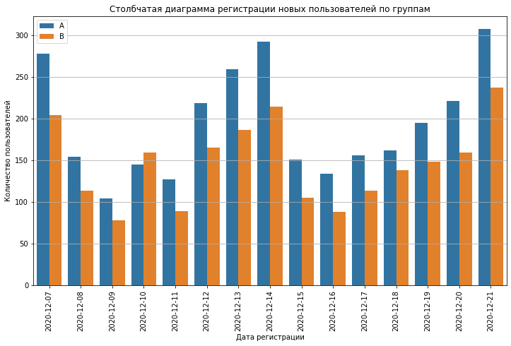

```python
plt.figure(figsize=(12, 7))
plt.grid(True)
plt.title('Столбчатая диаграмма регистрации новых пользователей по группам')
sns.barplot(x="first_date", y="user_id", hue="group", data=final_ab_new_users_aggregated)
ax = plt.gca()
ax.set_xlabel('Дата регистрации')
ax.set_ylabel('Количество пользователей')
plt.xticks(rotation=90)
plt.legend();
```

**Вывод:** в группе A больше пользователей, чем в группе B, однако количество регистрирующихся пользователей соразмерно.

Объединим датасеты `final_ab_events` и `final_ab_participants_2`.

```python
final_ab_events = final_ab_events.merge(final_ab_participants_2, left_on='user_id', right_on='user_id', how='left')
```

```python
final_ab_events.sample(10)
```

|  | user_id | event_dt | event_name | details | group | ab_test |
| --- | --- | --- | --- | --- | --- | --- |
| 232121 | F350C1D93F0FC93B | 2020-12-24 17:02:34 | product_page | 0.0 | NaN | NaN |
| 152093 | 0CD6EAE41098F14B | 2020-12-13 05:12:19 | product_page | 0.0 | NaN | NaN |
| 352963 | B736A7FBBABDD38A | 2020-12-19 13:32:47 | login | 0.0 | NaN | NaN |
| 269563 | C37734DB5C5C884B | 2020-12-10 17:18:16 | login | 0.0 | NaN | NaN |
| 419883 | 29D1CF72F700895D | 2020-12-26 10:50:27 | login | 0.0 | NaN | NaN |
| 138797 | 9F23ACAA71652544 | 2020-12-10 11:58:06 | product_page | 0.0 | NaN | NaN |
| 252604 | 18606A4332D75F80 | 2020-12-07 10:35:16 | login | 0.0 | NaN | NaN |
| 354519 | 5C3E4076556B8893 | 2020-12-19 01:44:53 | login | 0.0 | NaN | NaN |
| 295755 | 7EAEB87666F67920 | 2020-12-14 23:35:51 | login | 0.0 | NaN | NaN |
| 111514 | D4A7372C28346255 | 2020-12-23 13:12:21 | product_cart | 0.0 | NaN | NaN |

Создадим сводную таблицу `EventNumber`, сгруппируем данные по группам A/B-теста, в качестве столбцов — названия события, посчитаем количество пользователей и выведем на экран.

```python
EventNumber = final_ab_events.pivot_table(index='group', columns='event_name', values='user_id', aggfunc='nunique')
EventNumber
```

| event_name group | login | product_cart | product_page | purchase |
| --- | --- | --- | --- | --- |
| A | 2082 | 631 | 1360 | 652 |
| B | 706 | 195 | 397 | 198 |

Добавим в `EventNumber` столбец `registration` с количеством зарегистрировавшихся пользователей.

```python
EventNumber['registration'] = [final_ab_new_users[final_ab_new_users['group'] == 'A'].shape[0], \
                               final_ab_new_users[final_ab_new_users['group'] == 'B'].shape[0]]
EventNumber
```

| event_name group | login | product_cart | product_page | purchase | registration |
| --- | --- | --- | --- | --- | --- |
| A | 2082 | 631 | 1360 | 652 | 2903 |
| B | 706 | 195 | 397 | 198 | 2196 |

Выделим группу A, отсортируем по убыванию числа событий и построим воронку.

```python
EventNumber_A = EventNumber.T['A'].sort_values(ascending=False)
EventNumber_A
```

```
event_name
registration    2903
login           2082
product_page    1360
purchase         652
product_cart     631
Name: A, dtype: int64
```

```python
fig = go.Figure(go.Funnel(
    y = EventNumber_A.index,
    x = EventNumber_A,
    hoverinfo = "percent initial+percent previous",
    ))
fig.show()
```

[interactive chart not shown]

Аналогично с группой B.

```python
EventNumber_B = EventNumber.T['B'].sort_values(ascending=False)
EventNumber_B
```

```
event_name
registration    2196
login            706
product_page     397
purchase         198
product_cart     195
Name: B, dtype: int64
```

```python
fig = go.Figure(go.Funnel(
    y = EventNumber_B.index,
    x = EventNumber_B,
    hoverinfo = "percent initial+percent previous",
    ))
fig.show()
```

[interactive chart not shown]

Объединим группы A и B обратно в `EventNumber` и добавим столбцы с % от предыдущего значения — `Previous` и % от общего — `Initial`.

```python
EventNumber = pd.DataFrame([EventNumber_A, EventNumber_B]).T

EventNumber['A_Previous'] = EventNumber['A'] / EventNumber['A'].shift()
EventNumber['A_Previous'] = EventNumber['A_Previous'].fillna(1)
EventNumber['A_Previous'] = EventNumber['A_Previous'].apply(lambda x: "{0:.1f}%".format(x * 100))

EventNumber['B_Previous'] = EventNumber['B'] / EventNumber['B'].shift()
EventNumber['B_Previous'] = EventNumber['B_Previous'].fillna(1)
EventNumber['B_Previous'] = EventNumber['B_Previous'].apply(lambda x: "{0:.1f}%".format(x * 100))

EventNumber['A_Initial'] = EventNumber['A'] / EventNumber.loc['registration', 'A']
EventNumber['A_Initial'] = EventNumber['A_Initial'].apply(lambda x: "{0:.1f}%".format(x * 100))

EventNumber['B_Initial'] = EventNumber['B'] / EventNumber.loc['registration', 'B']
EventNumber['B_Initial'] = EventNumber['B_Initial'].apply(lambda x: "{0:.1f}%".format(x * 100))
EventNumber
```

| event_name | A | B | A_Previous | B_Previous | A_Initial | B_Initial |
| --- | --- | --- | --- | --- | --- | --- |
| registration | 2903 | 2196 | 100.0% | 100.0% | 100.0% | 100.0% |
| login | 2082 | 706 | 71.7% | 32.1% | 71.7% | 32.1% |
| product_page | 1360 | 397 | 65.3% | 56.2% | 46.8% | 18.1% |
| purchase | 652 | 198 | 47.9% | 49.9% | 22.5% | 9.0% |
| product_cart | 631 | 195 | 96.8% | 98.5% | 21.7% | 8.9% |

**Вывод:** количество залогинившихся после регистрации в группе B резко упало — с 71.7% до 32.1%. Итоговая конверсия в просмотры продуктов для группы B снизилась с 65.3% до 56.2%, а конверсии в покупки и в переход на страницу оплаты картой выросли незначительно — с 47.9% до 49.9% и с 96.8% до 98.5%.

Выделим участников теста в датасет `final_ab_events_recommender_system_test`.

```python
final_ab_events_recommender_system_test = final_ab_events[final_ab_events['ab_test'] == 'recommender_system_test']
final_ab_events_recommender_system_test.sample(5)
```

|  | user_id | event_dt | event_name | details | group | ab_test |
| --- | --- | --- | --- | --- | --- | --- |
| 96045 | FDF5D9D1B047FA31 | 2020-12-19 08:37:44 | product_cart | 0.00 | B | recommender_system_test |
| 17577 | 3766B1A346B48864 | 2020-12-14 04:59:27 | purchase | 4.99 | B | recommender_system_test |
| 189715 | 683331D56191FA80 | 2020-12-19 13:22:11 | product_page | 0.00 | A | recommender_system_test |
| 357025 | 5FED9C8EB157278D | 2020-12-20 09:35:17 | login | 0.00 | B | recommender_system_test |
| 261380 | 80313F5B33116510 | 2020-12-09 00:01:47 | login | 0.00 | A | recommender_system_test |

Посчитаем количество событий на пользователя.

```python
EventsByUsers = final_ab_events_recommender_system_test.\
groupby(['user_id', 'group'], as_index=False).agg({'event_name' : 'count'})
EventsByUsers.columns = ['user_id', 'group', 'events']
EventsByUsers.head(10)
```

|  | user_id | group | events |
| --- | --- | --- | --- |
| 0 | 0010A1C096941592 | A | 12 |
| 1 | 003DF44D7589BBD4 | A | 15 |
| 2 | 00505E15A9D81546 | A | 5 |
| 3 | 005E096DBD379BCF | B | 4 |
| 4 | 006E3E4E232CE760 | A | 6 |
| 5 | 00A52DCF85F1BE03 | A | 2 |
| 6 | 00C1F5175586DFCF | A | 9 |
| 7 | 010DF73DACCC1534 | A | 4 |
| 8 | 01157AAD4401952B | A | 9 |
| 9 | 0145A5A1EC388D99 | A | 4 |

Проанализируем количество событий по пользователям группы A методом `describe()`.

```python
EventsByUsers[EventsByUsers['group'] == 'A']['events'].describe()
```

```
count    2082.000000
mean        7.078290
std         3.882726
min         1.000000
25%         4.000000
50%         6.000000
75%         9.000000
max        24.000000
Name: events, dtype: float64
```

Проанализируем количество событий по пользователям группы B методом `describe()`.

```python
EventsByUsers[EventsByUsers['group'] == 'B']['events'].describe()
```

```
count    706.000000
mean       5.760623
std        3.484219
min        1.000000
25%        3.000000
50%        5.000000
75%        8.000000
max       28.000000
Name: events, dtype: float64
```

Сравним гистрограммы распределения количества событий на одного пользователя в каждой группе.

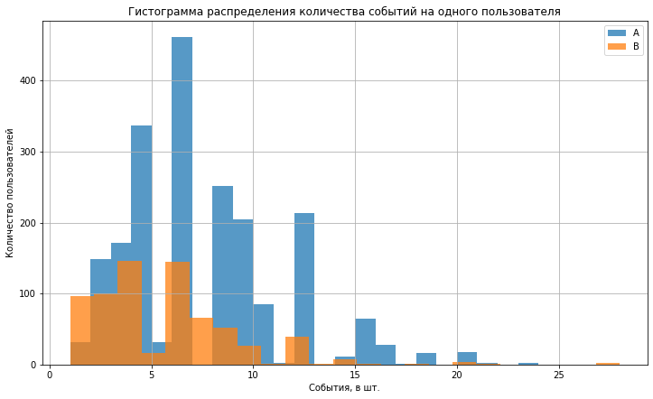

```python
EventsByUsers[EventsByUsers['group'] == 'A']['events'].\
hist(figsize=(12, 7), bins=len(EventsByUsers['events'].unique()), alpha=0.75, label='A')

EventsByUsers[EventsByUsers['group'] == 'B']['events'].\
hist(figsize=(12, 7), bins=len(EventsByUsers['events'].unique()), alpha=0.75, label='B')

ax = plt.gca()
ax.set_xlabel('События, в шт.')
ax.set_ylabel('Количество пользователей')
plt.legend()
plt.title('Гистограмма распределения количества событий на одного пользователя');
```

Построим точечную диаграмму числа событий на одного пользователя.

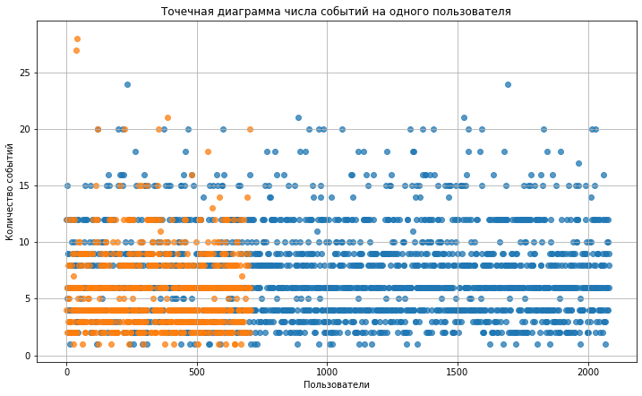

```python
A_values = pd.Series(range(0,len(EventsByUsers[EventsByUsers['group'] == 'A']['events'])))
B_values = pd.Series(range(0,len(EventsByUsers[EventsByUsers['group'] == 'B']['events'])))

plt.figure(figsize=(12, 7))
plt.grid(True)
plt.title('Точечная диаграмма числа событий на одного пользователя')
ax = plt.gca()
ax.set_xlabel('Пользователи')
ax.set_ylabel('Количество событий')
plt.scatter(A_values, EventsByUsers[EventsByUsers['group'] == 'A']['events'], alpha=0.75, label='A')
plt.scatter(B_values, EventsByUsers[EventsByUsers['group'] == 'B']['events'], alpha=0.75, label='B');
```

**Вывод:** с учётом того, что группа A многочисленнее группы B, количество событий на пользователя в выборках распределено одинаково.

Добавим в датасет `final_ab_events_recommender_system_test` столбец `event_dt_day`, сохранив только год, месяц, день.

```python
final_ab_events_recommender_system_test['event_dt_day'] = final_ab_events_recommender_system_test['event_dt'].dt.date
final_ab_events_recommender_system_test.sample(5)
```

|  | user_id | event_dt | event_name | details | group | ab_test | event_dt_day |
| --- | --- | --- | --- | --- | --- | --- | --- |
| 355872 | 279C6150111EB3D3 | 2020-12-20 03:09:42 | login | 0.00 | A | recommender_system_test | 2020-12-20 |
| 430954 | A4FB6B61C861EB1F | 2020-12-27 11:50:00 | login | 0.00 | A | recommender_system_test | 2020-12-27 |
| 31559 | A9F4C82F705BDAF9 | 2020-12-19 00:30:52 | purchase | 4.99 | A | recommender_system_test | 2020-12-19 |
| 248261 | F18135D5B8BF0093 | 2020-12-29 13:12:50 | product_page | 0.00 | A | recommender_system_test | 2020-12-29 |
| 96588 | 16E66DD220E6B6F5 | 2020-12-19 20:15:38 | product_cart | 0.00 | B | recommender_system_test | 2020-12-19 |

```python
final_ab_events_recommender_system_test_aggregated = final_ab_events_recommender_system_test\
.groupby(['event_dt_day', 'group']).agg({'event_name':'count'}).reset_index()
final_ab_events_recommender_system_test_aggregated.head(10)
```

|  | event_dt_day | group | event_name |
| --- | --- | --- | --- |
| 0 | 2020-12-07 | A | 234 |
| 1 | 2020-12-07 | B | 290 |
| 2 | 2020-12-08 | A | 267 |
| 3 | 2020-12-08 | B | 183 |
| 4 | 2020-12-09 | A | 296 |
| 5 | 2020-12-09 | B | 273 |
| 6 | 2020-12-10 | A | 265 |
| 7 | 2020-12-10 | B | 196 |
| 8 | 2020-12-11 | A | 282 |
| 9 | 2020-12-11 | B | 122 |

Визуализируем.

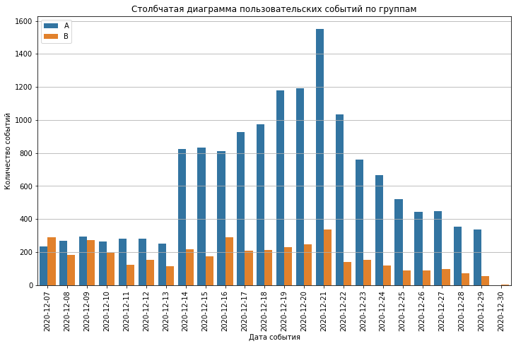

```python
plt.figure(figsize=(12, 7))
plt.grid(True)
plt.title('Столбчатая диаграмма пользовательских событий по группам')
sns.barplot(x="event_dt_day", y="event_name", hue="group", data=final_ab_events_recommender_system_test_aggregated)
ax = plt.gca()
ax.set_xlabel('Дата события')
ax.set_ylabel('Количество событий')
plt.xticks(rotation=90)
plt.legend();
```

**Вывод:** пользовательская активность достигает пика к 2020-12-21. Связано ли это с остановкой набора новых пользователей или с началом *Christmas&New Year Promo*?

### К оглавлению

## Шаг 3. Оценка результатов A/B-тестирования

- Что можно сказать про результаты A/В-тестирования?
- Проверьте статистическую разницу долей z-критерием.

Посчитаем количество покупок и суммарный чек по дням. Выберем в датасете `final_ab_events_recommender_system_test` события `purchase`, сгруппируем его по дню события и группе A/B-теста, посчитаем количество покупок и суммарный чек. Сбросим индексы методом `reset_index()`. Сохраним результат в переменную `final_ab_events_recommender_system_test_purchase`.

```python
final_ab_events_recommender_system_test_purchase = final_ab_events_recommender_system_test[
    final_ab_events_recommender_system_test['event_name'] == 'purchase'].\
groupby(['event_dt_day', 'group']).agg({'event_name':'count', 'details':'sum'}).reset_index()
final_ab_events_recommender_system_test_purchase.head(10)
```

|  | event_dt_day | group | event_name | details |
| --- | --- | --- | --- | --- |
| 0 | 2020-12-07 | A | 30 | 744.70 |
| 1 | 2020-12-07 | B | 47 | 639.53 |
| 2 | 2020-12-08 | A | 30 | 734.70 |
| 3 | 2020-12-08 | B | 26 | 344.74 |
| 4 | 2020-12-09 | A | 43 | 1324.57 |
| 5 | 2020-12-09 | B | 28 | 354.72 |
| 6 | 2020-12-10 | A | 38 | 1189.62 |
| 7 | 2020-12-10 | B | 20 | 609.80 |
| 8 | 2020-12-11 | A | 33 | 959.67 |
| 9 | 2020-12-11 | B | 11 | 69.89 |

Объединим таблицы `final_ab_events_recommender_system_test_aggregated` и `final_ab_events_recommender_system_test_purchase`. Изменим заголовки.

```python
final_ab_events_recommender_system_test_aggregated = final_ab_events_recommender_system_test_aggregated.merge(
    final_ab_events_recommender_system_test_purchase, \
    left_on=['event_dt_day', 'group'], \
    right_on=['event_dt_day', 'group'], how='left')
final_ab_events_recommender_system_test_aggregated.columns = ['date', 'group', 'events', 'purchases', 'revenue']
final_ab_events_recommender_system_test_aggregated.head(10)
```

|  | date | group | events | purchases | revenue |
| --- | --- | --- | --- | --- | --- |
| 0 | 2020-12-07 | A | 234 | 30.0 | 744.70 |
| 1 | 2020-12-07 | B | 290 | 47.0 | 639.53 |
| 2 | 2020-12-08 | A | 267 | 30.0 | 734.70 |
| 3 | 2020-12-08 | B | 183 | 26.0 | 344.74 |
| 4 | 2020-12-09 | A | 296 | 43.0 | 1324.57 |
| 5 | 2020-12-09 | B | 273 | 28.0 | 354.72 |
| 6 | 2020-12-10 | A | 265 | 38.0 | 1189.62 |
| 7 | 2020-12-10 | B | 196 | 20.0 | 609.80 |
| 8 | 2020-12-11 | A | 282 | 33.0 | 959.67 |
| 9 | 2020-12-11 | B | 122 | 11.0 | 69.89 |

Сконкатенируем по группам кумулятивные данные о заказах, покупателях и выручке методом `pd.concat()` и сохраним в столбцы `events_cum`, `purchases_cum`, `revenue_cum` соответственно.

```python
final_ab_events_recommender_system_test_aggregated[['events_cum', 'purchases_cum', 'revenue_cum']] = pd.concat(
    [final_ab_events_recommender_system_test_aggregated[
        final_ab_events_recommender_system_test_aggregated['group'] == 'A'][['events', 'purchases', 'revenue']].cumsum(), \
     final_ab_events_recommender_system_test_aggregated[
        final_ab_events_recommender_system_test_aggregated['group'] == 'B'][['events', 'purchases', 'revenue']].cumsum()])
final_ab_events_recommender_system_test_aggregated.head(10)
```

|  | date | group | events | purchases | revenue | events_cum | purchases_cum | revenue_cum |
| --- | --- | --- | --- | --- | --- | --- | --- | --- |
| 0 | 2020-12-07 | A | 234 | 30.0 | 744.70 | 234.0 | 30.0 | 744.70 |
| 1 | 2020-12-07 | B | 290 | 47.0 | 639.53 | 290.0 | 47.0 | 639.53 |
| 2 | 2020-12-08 | A | 267 | 30.0 | 734.70 | 501.0 | 60.0 | 1479.40 |
| 3 | 2020-12-08 | B | 183 | 26.0 | 344.74 | 473.0 | 73.0 | 984.27 |
| 4 | 2020-12-09 | A | 296 | 43.0 | 1324.57 | 797.0 | 103.0 | 2803.97 |
| 5 | 2020-12-09 | B | 273 | 28.0 | 354.72 | 746.0 | 101.0 | 1338.99 |
| 6 | 2020-12-10 | A | 265 | 38.0 | 1189.62 | 1062.0 | 141.0 | 3993.59 |
| 7 | 2020-12-10 | B | 196 | 20.0 | 609.80 | 942.0 | 121.0 | 1948.79 |
| 8 | 2020-12-11 | A | 282 | 33.0 | 959.67 | 1344.0 | 174.0 | 4953.26 |
| 9 | 2020-12-11 | B | 122 | 11.0 | 69.89 | 1064.0 | 132.0 | 2018.68 |

Выделим датафреймы с кумулятивным количеством заказов и кумулятивной выручкой по дням в группе А и в группе B.

```python
cumulativeRevenueA = final_ab_events_recommender_system_test_aggregated[
    final_ab_events_recommender_system_test_aggregated['group'] == 'A'][['date','purchases_cum', 'revenue_cum']]

cumulativeRevenueB = final_ab_events_recommender_system_test_aggregated[
    final_ab_events_recommender_system_test_aggregated['group'] == 'B'][['date','purchases_cum', 'revenue_cum']]
```

Построим графики кумулятивной выручки по дням и группам A/B-тестирования.

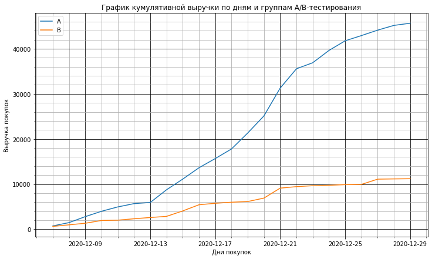

```python
plt.figure(figsize=(12, 7))
plt.grid(True)
plt.title('График кумулятивной выручки по дням и группам A/B-тестирования')

# строим график выручки группы А
plt.plot(cumulativeRevenueA['date'], cumulativeRevenueA['revenue_cum'], label='A')

# строим график выручки группы B
plt.plot(cumulativeRevenueB['date'], cumulativeRevenueB['revenue_cum'], label='B')

ax = plt.gca()
ax.minorticks_on()
ax.grid(which='major', color = 'k')
ax.grid(which='minor')
ax.set_xlabel('Дни покупок')
ax.set_ylabel('Выручка покупок')

plt.legend();
```

**Вывод:** выручка группы B растёт медленнее.

Построим графики среднего чека по группам — разделим кумулятивную выручку на кумулятивное число заказов.

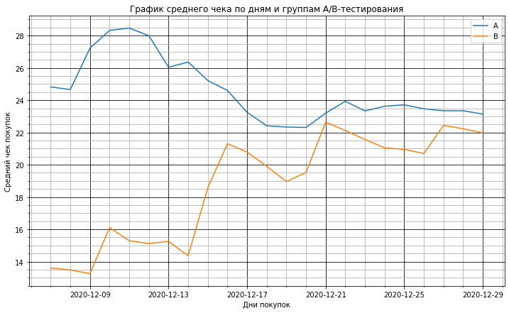

```python
plt.figure(figsize=(12, 7))
plt.grid(True)
plt.title('График среднего чека по дням и группам A/B-тестирования')

plt.plot(cumulativeRevenueA['date'], cumulativeRevenueA['revenue_cum'] / cumulativeRevenueA['purchases_cum'], label='A')
plt.plot(cumulativeRevenueB['date'], cumulativeRevenueB['revenue_cum'] / cumulativeRevenueB['purchases_cum'], label='B')

ax = plt.gca()
ax.minorticks_on()
ax.grid(which='major', color = 'k')
ax.grid(which='minor')
ax.set_xlabel('Дни покупок')
ax.set_ylabel('Средний чек покупок')

plt.legend();
```

**Вывод:** средний чек группы A сперва растёт до 2020-12-11, затем убывает до 2020-12-20, после чего стабилизируется. Средний чек группы B скачкообразно растёт до 2020-12-21, затем стабилизируется.

Построим график относительного изменения кумулятивного среднего чека. Соберём данные в одном датафрейме.

```python
mergedCumulativeRevenue = cumulativeRevenueA.merge(
    cumulativeRevenueB, left_on='date', right_on='date', how='left', suffixes=['A', 'B'])
mergedCumulativeRevenue.head(10)
```

|  | date | purchases_cumA | revenue_cumA | purchases_cumB | revenue_cumB |
| --- | --- | --- | --- | --- | --- |
| 0 | 2020-12-07 | 30.0 | 744.70 | 47.0 | 639.53 |
| 1 | 2020-12-08 | 60.0 | 1479.40 | 73.0 | 984.27 |
| 2 | 2020-12-09 | 103.0 | 2803.97 | 101.0 | 1338.99 |
| 3 | 2020-12-10 | 141.0 | 3993.59 | 121.0 | 1948.79 |
| 4 | 2020-12-11 | 174.0 | 4953.26 | 132.0 | 2018.68 |
| 5 | 2020-12-12 | 203.0 | 5682.97 | 154.0 | 2328.46 |
| 6 | 2020-12-13 | 228.0 | 5937.72 | 171.0 | 2608.29 |
| 7 | 2020-12-14 | 332.0 | 8751.68 | 199.0 | 2858.01 |
| 8 | 2020-12-15 | 441.0 | 11120.59 | 219.0 | 4067.81 |
| 9 | 2020-12-16 | 554.0 | 13629.46 | 255.0 | 5432.45 |

Визуализируем.

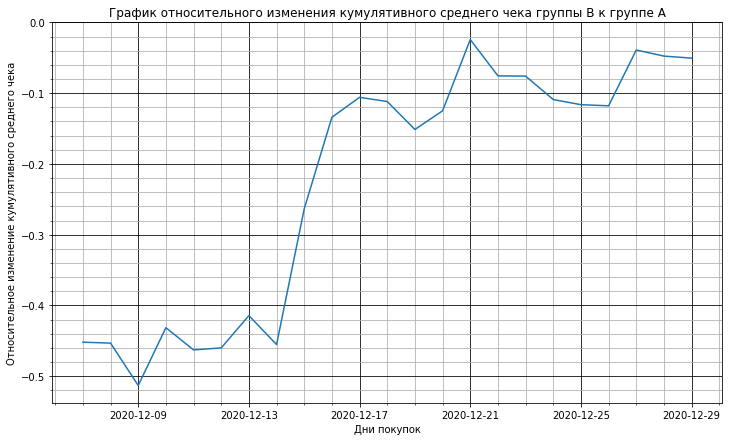

```python
# cтроим отношение средних чеков
plt.figure(figsize=(12, 7))
plt.grid(True)
plt.title('График относительного изменения кумулятивного среднего чека группы B к группе A')
plt.plot(mergedCumulativeRevenue['date'], \
         (mergedCumulativeRevenue['revenue_cumB']/mergedCumulativeRevenue['purchases_cumB'])/ \
         (mergedCumulativeRevenue['revenue_cumA']/mergedCumulativeRevenue['purchases_cumA'])-1)

ax = plt.gca()
ax.minorticks_on()
ax.grid(which='major', color = 'k')
ax.grid(which='minor')
ax.set_xlabel('Дни покупок')
ax.set_ylabel('Относительное изменение кумулятивного среднего чека');
```

**Вывод:** средние чеки групп A и B ближе всего после 2020-12-21.

Считаем кумулятивную конверсию в покупки.

```python
final_ab_events_recommender_system_test_aggregated['conversion'] = \
final_ab_events_recommender_system_test_aggregated['purchases_cum'] /\
final_ab_events_recommender_system_test_aggregated['events_cum']
```

Отделяем данные по группе A и B.

```python
cumulativeDataA = final_ab_events_recommender_system_test_aggregated[
    final_ab_events_recommender_system_test_aggregated['group'] == 'A']
```

```python
cumulativeDataB = final_ab_events_recommender_system_test_aggregated[
    final_ab_events_recommender_system_test_aggregated['group'] == 'B']
```

Визуализируем.

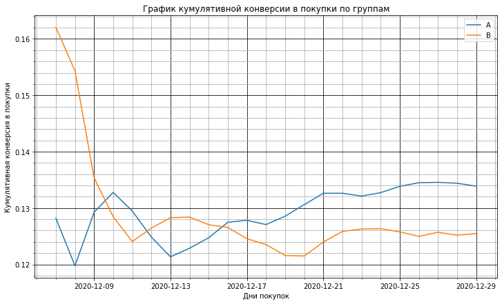

```python
plt.figure(figsize=(12, 7))
plt.grid(True)
plt.title('График кумулятивной конверсии в покупки по группам')

plt.plot(cumulativeDataA['date'], cumulativeDataA['conversion'], label='A')
plt.plot(cumulativeDataB['date'], cumulativeDataB['conversion'], label='B')

ax = plt.gca()
ax.minorticks_on()
ax.grid(which='major', color = 'k')
ax.grid(which='minor')
ax.set_xlabel('Дни покупок')
ax.set_ylabel('Кумулятивная конверсия в покупки')
plt.legend();
```

**Вывод:** кумулятивная конверсия в покупки группы B хуже группы A с 2020-12-16.

Подтвердим вывод, построив график относительного различия кумулятивных конверсий.

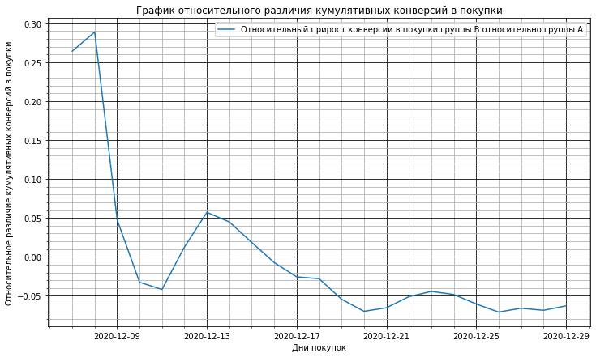

```python
mergedCumulativeConversions = cumulativeDataA[['date','conversion']].merge(
    cumulativeDataB[['date','conversion']], left_on='date', right_on='date', how='left', suffixes=['A', 'B'])

plt.figure(figsize=(12, 7))
plt.grid(True)
plt.title('График относительного различия кумулятивных конверсий в покупки')

plt.plot(mergedCumulativeConversions['date'], \
         mergedCumulativeConversions['conversionB']/mergedCumulativeConversions['conversionA']-1, \
         label="Относительный прирост конверсии в покупки группы B относительно группы A")

ax = plt.gca()
ax.minorticks_on()
ax.grid(which='major', color = 'k')
ax.grid(which='minor')
ax.set_xlabel('Дни покупок')
ax.set_ylabel('Относительное различие кумулятивных конверсий в покупки')
plt.legend();
```

Подготовим данные для A/В-тестирования. Выберем в датасете `final_ab_events_recommender_system_test` события `purchase`, сгруппируем его по пользователям и группе A/B-теста, посчитаем количество событий. Сохраним результат в переменную `purchasesByUsers`.

```python
purchasesByUsers = final_ab_events_recommender_system_test[
    final_ab_events_recommender_system_test['event_name'] == 'purchase'].groupby(['user_id', 'group'], as_index=False).\
agg({'event_name' : 'count'})
purchasesByUsers.head()
```

|  | user_id | group | event_name |
| --- | --- | --- | --- |
| 0 | 0010A1C096941592 | A | 4 |
| 1 | 005E096DBD379BCF | B | 2 |
| 2 | 00C1F5175586DFCF | A | 3 |
| 3 | 01157AAD4401952B | A | 3 |
| 4 | 0145A5A1EC388D99 | A | 2 |

Выделим покупки пользователей группы A.

```python
purchasesByUsersA = purchasesByUsers[purchasesByUsers['group'] == 'A']
purchasesByUsersA.head()
```

|  | user_id | group | event_name |
| --- | --- | --- | --- |
| 0 | 0010A1C096941592 | A | 4 |
| 2 | 00C1F5175586DFCF | A | 3 |
| 3 | 01157AAD4401952B | A | 3 |
| 4 | 0145A5A1EC388D99 | A | 2 |
| 5 | 0178FA423606B54B | A | 4 |

И группы B.

```python
purchasesByUsersB = purchasesByUsers[purchasesByUsers['group'] == 'B']
purchasesByUsersB.head()
```

|  | user_id | group | event_name |
| --- | --- | --- | --- |
| 1 | 005E096DBD379BCF | B | 2 |
| 15 | 058CE187A2C73865 | B | 1 |
| 18 | 05DCEB320AC0EE44 | B | 3 |
| 22 | 064FE8E188AB79E1 | B | 1 |
| 36 | 0997EC1C4850B27B | B | 4 |

Общее число событий для группы A.

```python
final_ab_events_recommender_system_test[final_ab_events_recommender_system_test['group'] == 'A']['event_name'].count()
```

```
14737
```

Общее число событий для группы B.

```python
final_ab_events_recommender_system_test[
    final_ab_events_recommender_system_test['group'] == 'B']['event_name'].count()
```

```
4067
```

Для подготовки выборок к проверке критерием Манна-Уитни объявим переменные `sampleA` и `sampleB`, в которых пользователям из разных групп будет соответствовать количество заказов. Тем, кто ничего не заказал, будут соответствовать нули.

Переменная `sampleA` состоит из двух частей:

1. Список с количеством заказов для каждого из пользователей: `purchasesByUsersA['event_name']`.
2. Нули для пользователей, которые ничего не заказывали. Их количество равно разнице между общим числом событий и количеством покупок: `final_ab_events_recommender_system_test[final_ab_events_recommender_system_test['group'] == 'A']['event_name'].count() - len(purchasesByUsersA['event_name'])`.

Создадим список индексов функцией `np.arange()`, создающей массив индексов в формате np.array, который требуется для `pd.Series`. Объединим последовательности функцией `pd.concat()` с добавлением параметра `axis=0` — по строкам.

```python
sampleA = pd.concat(
    [purchasesByUsersA['event_name'],pd.Series(0, index=np.arange(
        final_ab_events_recommender_system_test[
            final_ab_events_recommender_system_test['group'] == 'A']['event_name'].count() - \
        len(purchasesByUsersA['event_name'])), name='event_name')], axis=0)
```

```python
sampleB = pd.concat(
    [purchasesByUsersB['event_name'],pd.Series(0, index=np.arange(
        final_ab_events_recommender_system_test[
            final_ab_events_recommender_system_test['group'] == 'B']['event_name'].count() - \
        len(purchasesByUsersB['event_name'])), name='event_name')], axis=0)
```

Сформулируем следующие гипотезы:

H₀: конверсии в покупку групп A и B совпадают.

Hₐ: конверсии в покупку групп A и B различаются.

```python
alpha = .05 # критический уровень статистической значимости

results = st.mannwhitneyu(sampleA, sampleB)
print('p-значение: ', "{0:.3f}".format(results.pvalue))

if (results.pvalue < alpha):
    print("Отвергаем нулевую гипотезу: разница статистически значима")
else:
    print("Не получилось отвергнуть нулевую гипотезу, вывод о различии сделать нельзя")

print("{0:.3f}".format(sampleB.mean()/sampleA.mean()-1))
```

```
p-значение:  0.140
Не получилось отвергнуть нулевую гипотезу, вывод о различии сделать нельзя
-0.063
```

**Вывод:** нет статистически значимой разницы между конверсиями в покупку групп A и B.

Проверим статистическую значимость различий в среднем чеке покупок между группами A и B. Сформулируем следующие гипотезы:

H₀: средний чек покупок групп A и B совпадают.

Hₐ: средний чек покупок групп A и B различается.

```python
results = st.mannwhitneyu(
    final_ab_events_recommender_system_test[final_ab_events_recommender_system_test['group'] == 'A']['details'], \
    final_ab_events_recommender_system_test[final_ab_events_recommender_system_test['group'] == 'B']['details'])

print('p-значение: ', "{0:.5f}".format(results.pvalue))

if (results.pvalue < alpha):
    print("Отвергаем нулевую гипотезу: разница статистически значима")
else:
    print("Не получилось отвергнуть нулевую гипотезу, вывод о различии сделать нельзя")

print("{0:.3f}".format(
    final_ab_events_recommender_system_test[
        final_ab_events_recommender_system_test['group'] == 'A']['details'].mean()/\
    final_ab_events_recommender_system_test[
        final_ab_events_recommender_system_test['group'] == 'B']['details'].mean()-1))
```

```
p-значение:  0.07652
Не получилось отвергнуть нулевую гипотезу, вывод о различии сделать нельзя
0.124
```

**Вывод** нет статистически значимой разницы между средним чеком групп A и B.

Сформулируем следующие гипотезы:

1.

```
H₀: нет оснований считать разными доли пользователей A и B по событию product_page.

Hₐ: есть значимая разница между долями пользователей A и B по событию product_page.
```

2.

```
H₀: нет оснований считать разными доли пользователей A и B по событиям purchase.

Hₐ: есть значимая разница между долями пользователей A и B по событиям purchase.
```

3.

```
H₀: нет оснований считать разными доли пользователей A и B по событиям product_cart.

Hₐ: есть значимая разница между долями пользователей A и B по событиям product_cart.
```

```python
EventNumber
```

| event_name | A | B | A_Previous | B_Previous | A_Initial | B_Initial |
| --- | --- | --- | --- | --- | --- | --- |
| registration | 2903 | 2196 | 100.0% | 100.0% | 100.0% | 100.0% |
| login | 2082 | 706 | 71.7% | 32.1% | 71.7% | 32.1% |
| product_page | 1360 | 397 | 65.3% | 56.2% | 46.8% | 18.1% |
| purchase | 652 | 198 | 47.9% | 49.9% | 22.5% | 9.0% |
| product_cart | 631 | 195 | 96.8% | 98.5% | 21.7% | 8.9% |

Проверим гипотезы в цикле по каждому событию.

```python
alpha = .05 # критический уровень статистической значимости

EventName = ['product_page', 'purchase', 'product_cart']

for i in EventName:
    # успехи
    successes = np.array([EventNumber.loc[i, 'A'], EventNumber.loc[i, 'B']])

    # всего
    trials = np.array([EventNumber.loc['login', 'A'], EventNumber.loc['login', 'B']])

    # пропорция успехов в первой группе:
    p1 = successes[0]/trials[0]

    # пропорция успехов во второй группе:
    p2 = successes[1]/trials[1]

    # пропорция успехов в комбинированном датасете:
    p_combined = (successes[0] + successes[1]) / (trials[0] + trials[1])

    # разница пропорций в датасетах
    difference = p1 - p2

    # считаем статистику в ст.отклонениях стандартного нормального распределения
    z_value = difference / math.sqrt(p_combined * (1 - p_combined) * (1/trials[0] + 1/trials[1]))

    # задаем стандартное нормальное распределение (среднее 0, ст.отклонение 1)
    distr = st.norm(0, 1)

    p_value = (1 - distr.cdf(abs(z_value))) * 2

    print('p-значение: ', "{0:.5f}".format(p_value))

    if (p_value < alpha):
        print("Отвергаем нулевую гипотезу: между группами A и B по событию", i, "есть значимая разница")
    else:
        print("Не получилось отвергнуть нулевую гипотезу, нет оснований считать доли выборок A и B по событию", i, "разными")
```

```
p-значение:  0.00002
Отвергаем нулевую гипотезу: между группами A и B по событию product_page есть значимая разница
p-значение:  0.10282
Не получилось отвергнуть нулевую гипотезу, нет оснований считать доли выборок A и B по событию purchase разными
p-значение:  0.17663
Не получилось отвергнуть нулевую гипотезу, нет оснований считать доли выборок A и B по событию product_cart разными
```

### К оглавлению

## Выводы

**Тест проведён некорректно и по проведённой оценке результатов A/B-тестирования следует признать его неуспешным.**

Время проведения теста совпадает с *Christmas&New Year Promo*, стартующим 2020-12-25.

Есть 1602 случая пересечений с конкурирующим тестом `interface_eu_test`. После их удаления количество участников теста составляет 5099, что меньше запланированных 6000.

В группе A больше пользователей, чем в группе B, однако количество регистрирующихся пользователей соразмерно.

Количество залогинившихся после регистрации в группе B резко упало — с 71.7% до 32.1%. Итоговая конверсия в просмотры продуктов для группы B снизилась с 65.3% до 56.2%, а конверсии в покупки и в переход на страницу оплаты картой выросли незначительно — с 47.9% до 49.9% и с 96.8% до 98.5%.

С учётом того, что группа A многочисленнее группы B, количество событий на пользователя в выборках распределено одинаково.

Пользовательская активность достигает пика к 2020-12-21. Связано ли это с остановкой набора новых пользователей или с началом *Christmas&New Year Promo*?

Выручка группы B растёт медленнее.

Средний чек группы A сперва растёт до 2020-12-11, затем убывает до 2020-12-20, после чего стабилизируется. Средний чек группы B скачкообразно растёт до 2020-12-21, затем стабилизируется.

Средние чеки групп A и B ближе всего после 2020-12-21.

Кумулятивная конверсия в покупки группы B хуже группы A с 2020-12-16.

Нет статистически значимой разницы между конверсиями в покупку групп A и B.

Нет статистически значимой разницы между средним чеком групп A и B.

### К оглавлению